# R3_Data_Visualization

Lou Reynolds

Sep 12, 2017

## Intro to Plotting in GGPLOT2

I am borrowing heavily from Hadley Wickham (creator of ggplot2)

Please bookmark:

http://ggplot2.tidyverse.org/reference/

Cookbook for R: http://www.cookbook-r.com/Graphs/

This is a great resource (also from Winston Chang) and always a click away.

A great introduction to why R is a smart way to make graphs can be viewed at:

http://vita.had.co.nz/papers/engineering-da.html

Hadley distills the reasons to use R for data analysis nicely:

**1) Reproducability**

**2) Automation**

**3) Text**

**4) Communication**

But there is a cost - R does have a **steep learning curve.**

For visualizing data, I have found this to be particularly true.

Once you find a plot that you like, it can be reproduced over and over again - just by changing a few lines of code.

A few books.

*Hadley Wickham*  
ggplot2: Elegant Graphics for Data Analysis 2nd ed. 2016 Edition

Comprehensive.

*Winston Chang*  
R Graphics Cookbook. 2012. O’Reilly and Associtates.

If I were to choose a textbook for GGPLOT2 (and R graphing in general), it would be Chang’s book.

*Hadley Wickham and Garrett Grolemund*  
R for Data Science. 2017. O’Reilly and Associtates.

Really nice book. Accessible and good to have at your desk.

## A bit about this workshop and this IDE

This workshop was created using RStudio, an integrated development environment (IDE). There are a lot of tools within RStudio that will help you wrangle, analyze, and report your data. Take a few minutes now to familiarize yourself with RStudio.

The code for this workshop is written as an R Markdown document.

You can find a quick explanation here: http://rmarkdown.rstudio.com/authoring_quick_tour.html

R Markdown can be used to produce html, pdf, and doc files of your analysis. It was used to produce this document.

R Markdown in R Studio also defaults to notebook view and allows for notebook html output. More on this here:

http://rmarkdown.rstudio.com/r_notebooks.html

Rmd is also a nice environment within which to write and execute code. Code is broken into Chunks, which can be executed separted. To run an entire chunk of code, use Ctrl+Alt+C More on this later in the workshop.

## The R environment

Before loading libraries one needs to get and install the packages **Then** load the libraries

For this workshop, we will be loading knitr, markdown, readxl, forcats, ggrepel, viridis, tidyverse, broom

*tidyverse* is a compilation,importing: *broom, dplyr, forcats, ggplot2, haven, httr, hms, jsonlite, lubridate, magrittr, modelr, purrr, readr, readxl, stringr, tibble, rvest, tidyr, xml2*

```r
library(knitr)
library(rmarkdown)
library(tidyverse)
library(readxl)
library(viridis)
library(forcats)
```

## Set the working directory

Create a folder - this will be your *working directory* You will need to modify the code for your computer. Can also be done at Session/Set Working Directory

Within code chunks, the # sign comments out lines Multiple lines can be commented/uncommented with Edit/comment/uncomment (Ctrl+Shift+C)

```r
setwd("C:/Users/lreynold/Desktop/R3EPA_R")
```

## Getting data into the R environment

readr is a package found in tidyverse and is useful for reading csv, csv2, tsv, or many other delimited files as well as text. It will automatically unzip compressed file. read_csv works better than read.csv. There are other methods as well (fread…)for large datasets A nice overview for importing data http://r4ds.had.co.nz/import.html

We will use readxl as it handles excel data nicely.

### NRSA data example

This dataset is from the National Rivers and Streams Assessment and is a subset of the entire NRSA dataset. It is site data with factors describing the site. These factors are categorical (eg. ecoregion) and continuous (eg. watershed area). Biological metrics, and stressor variables are also in columns.

You can list sheets with **excel_sheets()** - which is handy when there are many sheets in a workbook.

```r
excel_sheets("VisData.xlsx")
```

```
## [1] "nrsa"     "all_fish" "bug_mmi"  "fish_mmi" "rawmets"
```

Read in the data

```r
nrsa = read_excel("VisData.xlsx","nrsa")
```

## Use functions to examine the tibble

```r
head(nrsa)
```

```
## # A tibble: 6 x 32
##     SITE_ID   DATE_COL NESZCL VISIT_NO STATE STRAHLERORDER
##       <chr>     <dttm>  <chr>    <dbl> <chr>         <chr>
## 1 FW08DE021 2008-07-29     1b        1    DE           2nd
## 2 FW08VT003 2008-07-01      2        1    VT           3rd
## 3 FW08VT004 2008-08-21     1b        1    VT           2nd
## 4 FW08VT005 2008-06-24     1b        1    VT           2nd
## 5 FW08VT007 2008-08-18     1a        1    VT           4th
## 6 FW08VT008 2008-07-30     1a        1    VT           2nd
## # ... with 26 more variables: RT_NRSA_CA <chr>, Disturbance <chr>,
## #   D_TEMPCL3 <chr>, D_SZCL4 <chr>, D_SZCL5 <chr>, LAT_DD83 <dbl>,
## #   LON_DD83 <dbl>, SITE_CLASS <chr>, ELECTROFISH <chr>, METHOD <chr>,
## #   RCH_LENGTH <dbl>, SAMPLE_TYPE <chr>, SAMPLED_FISH <chr>, KM2 <dbl>,
## #   TOTLNIND <dbl>, BENTINVNTAX <dbl>, PBenInd <dbl>, COLDNTAX <dbl>,
## #   COLDPIND <dbl>, INTLINVNTAX <dbl>, INTLINVPIND <dbl>, INVNTAX <dbl>,
## #   NAT_LITHNTAX <dbl>, NATTAX <dbl>, RHEONTAX <dbl>, FISHMMI <dbl>
```

```r
tail (nrsa)
```

```
## # A tibble: 6 x 32
##     SITE_ID   DATE_COL NESZCL VISIT_NO STATE STRAHLERORDER
##       <chr>     <dttm>  <chr>    <dbl> <chr>         <chr>
## 1 FW08PA006 2009-07-15     1b        1    PA           2nd
## 2 FW08PA030 2009-09-02     3b        1    PA           6th
## 3 FW08CT003 2009-09-09     1a        1    CT           1st
## 4 FW08CT027 2009-09-16     1a        1    CT           1st
## 5 FW08CT008 2009-09-23     1a        1    CT           2nd
## 6 FW08CT004 2009-09-01     1a        1    CT           2nd
## # ... with 26 more variables: RT_NRSA_CA <chr>, Disturbance <chr>,
## #   D_TEMPCL3 <chr>, D_SZCL4 <chr>, D_SZCL5 <chr>, LAT_DD83 <dbl>,
## #   LON_DD83 <dbl>, SITE_CLASS <chr>, ELECTROFISH <chr>, METHOD <chr>,
## #   RCH_LENGTH <dbl>, SAMPLE_TYPE <chr>, SAMPLED_FISH <chr>, KM2 <dbl>,
## #   TOTLNIND <dbl>, BENTINVNTAX <dbl>, PBenInd <dbl>, COLDNTAX <dbl>,
## #   COLDPIND <dbl>, INTLINVNTAX <dbl>, INTLINVPIND <dbl>, INVNTAX <dbl>,
## #   NAT_LITHNTAX <dbl>, NATTAX <dbl>, RHEONTAX <dbl>, FISHMMI <dbl>
```

```r
names(nrsa)
```

```
##  [1] "SITE_ID"       "DATE_COL"      "NESZCL"        "VISIT_NO"
##  [5] "STATE"         "STRAHLERORDER" "RT_NRSA_CA"    "Disturbance"
##  [9] "D_TEMPCL3"     "D_SZCL4"       "D_SZCL5"       "LAT_DD83"
## [13] "LON_DD83"      "SITE_CLASS"    "ELECTROFISH"   "METHOD"
## [17] "RCH_LENGTH"    "SAMPLE_TYPE"   "SAMPLED_FISH"  "KM2"
## [21] "TOTLNIND"      "BENTINVNTAX"   "PBenInd"       "COLDNTAX"
## [25] "COLDPIND"      "INTLINVNTAX"   "INTLINVPIND"   "INVNTAX"
## [29] "NAT_LITHNTAX"  "NATTAX"        "RHEONTAX"      "FISHMMI"
```

```r
class(nrsa)
```

```
## [1] "tbl_df"     "tbl"        "data.frame"
```

```r
str(nrsa)
```

```
## Classes 'tbl_df', 'tbl' and 'data.frame':    313 obs. of  32 variables:
##  $ SITE_ID      : chr  "FW08DE021" "FW08VT003" "FW08VT004" "FW08VT005" ...
##  $ DATE_COL     : POSIXct, format: "2008-07-29" "2008-07-01" ...
##  $ NESZCL       : chr  "1b" "2" "1b" "1b" ...
##  $ VISIT_NO     : num  1 1 1 1 1 1 1 1 1 1 ...
##  $ STATE        : chr  "DE" "VT" "VT" "VT" ...
##  $ STRAHLERORDER: chr  "2nd" "3rd" "2nd" "2nd" ...
##  $ RT_NRSA_CA   : chr  "Intermediate Disturbance" "Least Disturbed" "Least Disturbed" "Least Disturbed" ...
##  $ Disturbance  : chr  "ModDist" "LikeRef" "LikeRef" "LikeRef" ...
##  $ D_TEMPCL3    : chr  "Transitional Cool" "Cold" "Cold" "Cold" ...
##  $ D_SZCL4      : chr  "Headwater/Creek" "Small River" "Headwater/Creek" "Headwater/Creek" ...
##  $ D_SZCL5      : chr  "Headwater/Creek" "Small River" "Headwater/Creek" "Headwater/Creek" ...
##  $ LAT_DD83     : num  39.7 43.9 44.8 44.2 43.9 ...
##  $ LON_DD83     : num  -75.7 -72.7 -72.1 -73 -72.8 ...
##  $ SITE_CLASS   : chr  "PROB" "PROB" "PROB" "PROB" ...
```

[output cut: 18 more lines]

```r
glimpse(nrsa)
```

```
## Observations: 313
## Variables: 32
## $ SITE_ID       <chr> "FW08DE021", "FW08VT003", "FW08VT004", "FW08VT00...
## $ DATE_COL      <dttm> 2008-07-29, 2008-07-01, 2008-08-21, 2008-06-24,...
## $ NESZCL        <chr> "1b", "2", "1b", "1b", "1a", "1a", "1a", "1b", "...
## $ VISIT_NO      <dbl> 1, 1, 1, 1, 1, 1, 1, 1, 1, 1, 1, 1, 1, 1, 1, 1, ...
## $ STATE         <chr> "DE", "VT", "VT", "VT", "VT", "VT", "MD", "MD", ...
## $ STRAHLERORDER <chr> "2nd", "3rd", "2nd", "2nd", "4th", "2nd", "1st",...
## $ RT_NRSA_CA    <chr> "Intermediate Disturbance", "Least Disturbed", "...
## $ Disturbance   <chr> "ModDist", "LikeRef", "LikeRef", "LikeRef", "Lik...
## $ D_TEMPCL3     <chr> "Transitional Cool", "Cold", "Cold", "Cold", "Co...
## $ D_SZCL4       <chr> "Headwater/Creek", "Small River", "Headwater/Cre...
## $ D_SZCL5       <chr> "Headwater/Creek", "Small River", "Headwater/Cre...
## $ LAT_DD83      <dbl> 39.70279, 43.94606, 44.80615, 44.21421, 43.90351...
## $ LON_DD83      <dbl> -75.69404, -72.71105, -72.13634, -72.96547, -72....
```

[output cut: 19 more lines]

The Sheets bug_mmi and fish_mmi are statistics These stats were run by the Corvallis ORD statisticians - we will present them in a plot later in the workshop.

```r
fish <- read_excel("VisData.xlsx","fish_mmi")
bugs <- read_excel("VisData.xlsx", "bug_mmi")
```

## Basic Graphing and GGPLOT2

ggplot2 is a graphing mini-language - GG stands for the Grammar of Graphics, a book and concept of Leland Wilkinson’s. ggplot2 is Hadley Wickham’s implementation of this concept. As Hadley puts it:

“A grammar of graphics is a tool that enables us to concisely describe the components for a graphic”

ggplot2 builds a graph in distinct pieces so that making changes and tweaks is less complicated.

This is all less complicated once you know how to build a graph.

Every question that I can imagine regarding ggplot has been asked somewhere on the web.

Google is your friend when it comes to learning this package.

Lets’s start by using R base graphics.  
**First variable = x, second variable = y.**

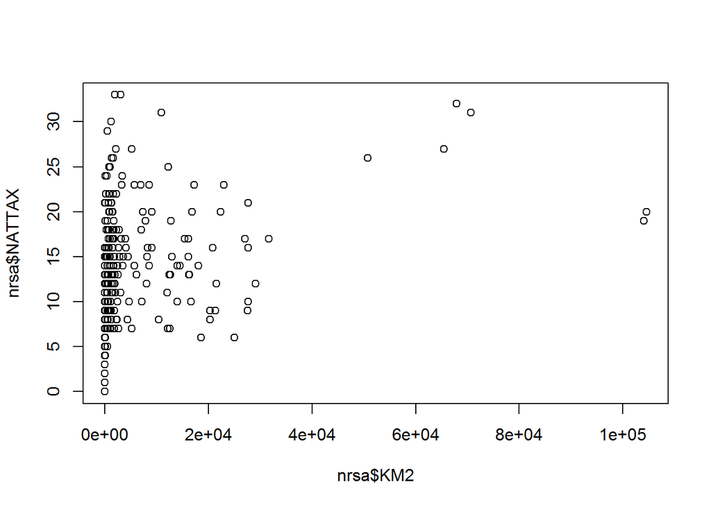

```r
plot(nrsa$KM2, nrsa$NATTAX)
```

Note that scientific notation is used on the x axis as default.

### The same graph using ggplot2.

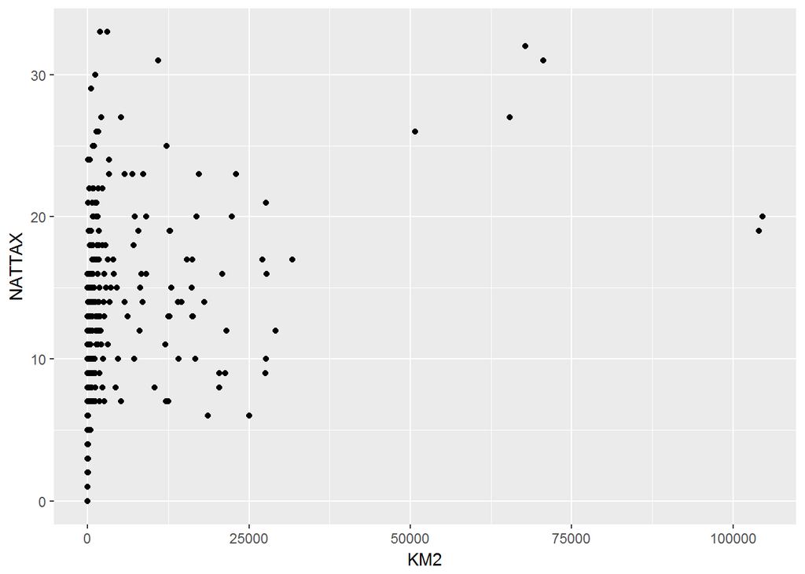

```r
ggplot(data=nrsa)+
  geom_point(mapping=aes(x=KM2, y=NATTAX))
```

## There are 3 parts to this plot.

### 1. The function ggplot() creates a cooridinate system within which to make the plot.

#### The **data=** call describes the dataset that will be plotted.

### 2. layers are added after +

#### These are geoms, prefaced by geom_ There are many different kinds of geoms (plots) that can be added to the coordinate system created by the ggplot call.

### 3. each layer then maps its own aesthetic or aes() into the coordinate system set up by ggplot().

#### aes(x= ,y= ) maps variables in the dataset to the x and y.

## Map aesthetics to variables

#### Colors, shapes, and sizes of points can add considerable information to plots.

#### To examine if there might be differeneces in different states, we could make the color of points correspond to the variable STATE in the dataset.

### This code will color points, but will not map them to a variable. The call is outside of aes():

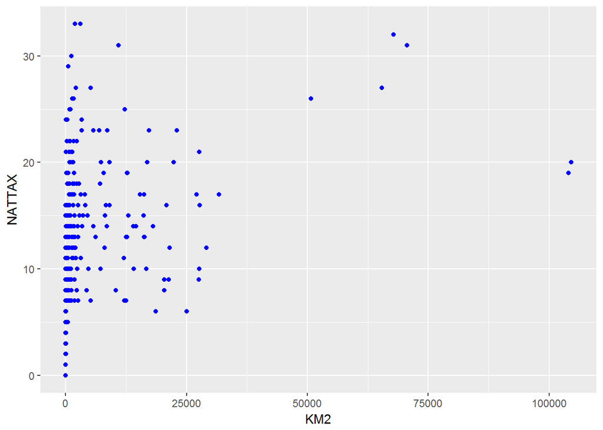

```r
ggplot(data=nrsa)+
  geom_point(mapping=aes(x=KM2, y=NATTAX), color="blue")
```

#### This code will map the variable STATE to different colors.

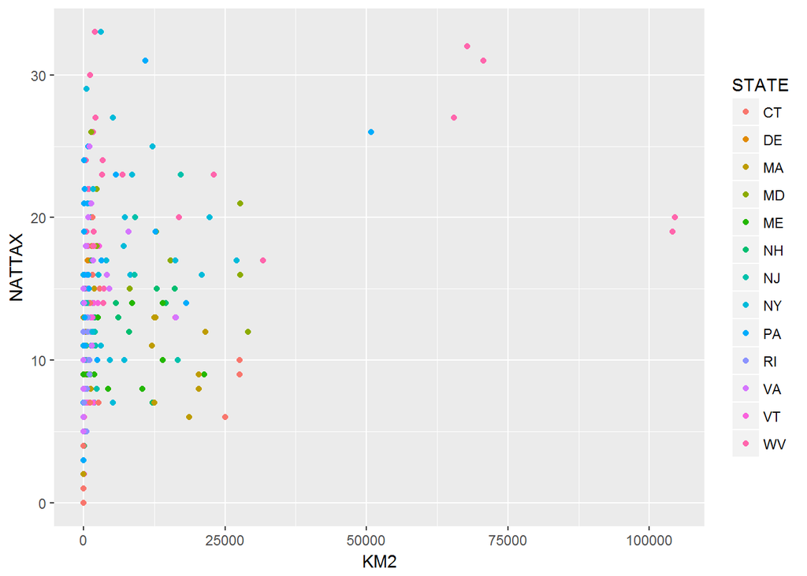

```r
ggplot(data=nrsa)+
  geom_point(mapping=aes(x=KM2, y=NATTAX, color=STATE))
```

#### Note that a lot of the data is smashed into the first 10% of the x axis indicating that a log scale might be more appropriate.

We can add a log scale and force the labels of the x axis to display as comma formatted:

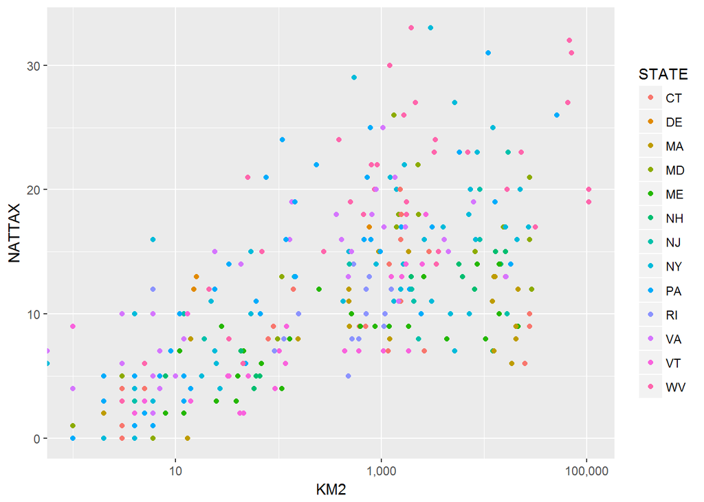

```r
ggplot(data=nrsa)+
  geom_point(mapping=aes(x=KM2, y=NATTAX, color=STATE))+
  scale_x_log10(labels=scales::comma)
```

We will take care of those infinite values in a bit (in this dataset, sites with no calculated watershed areas were given a 0 instead of NA).

## Add axis labels and titles with labs()

#### Add an annotation for the log tick marks.

This annotation is controllable for other log scales

```r
ggplot(data=nrsa)+
  geom_point(mapping=aes(x=KM2, y=NATTAX, color=STATE))+
  scale_x_log10(labels=scales::comma)+
labs(title="NRSA data Region 1,2,3", x="Watershed Area(Km2)",y="Native Fish Taxa")+
  annotation_logticks(sides="b", short = unit(.5,"mm"),
  mid = unit(3,"mm"),long = unit(4,"mm"))
```

## Writing ggplot() calls

#### If we are going to use the same data and mapping of x,y data in all the layers of the plot, it is good practice to write that into the ggplot() call. That mapping then applies to the entire plot.

There may be occcassion to add layers to plots that either plot subsets of data or apply models to groups of data - then you should include the mapping call within each layer as we did above.  
The shorthand version of the above code that ggplot2 uses is:

```r
ggplot(nrsa, aes(KM2, NATTAX))+
  geom_point(aes(color=STATE))+
  scale_x_log10(labels=scales::comma)+
labs(title="NRSA data Region 1,2,3", x="Watershed Area(Km2)",y="Native Fish Taxa")+
   annotation_logticks(sides="b", short = unit(.5,"mm"),
  mid = unit(3,"mm"),long = unit(4,"mm"))
```

## Naming Plots

Most times in discussions of ggplot2 on the web and in texts, plots are named and added to. You might also want to name plots in your code so that you can save them in memory.

Note that R allows either = or <- for creating an object.

```r
p <- ggplot(nrsa, aes(KM2, NATTAX))+
  geom_point(aes(color=STATE))+
  scale_x_log10(labels=scales::comma)+
   annotation_logticks(sides="b", short = unit(.5,"mm"),
  mid = unit(3,"mm"),long = unit(4,"mm"))
```

### p is now that object.

You will see this kind of shorthand a lot on answers submited to websites or in books. I discourage it when analyzing data because it can get a little confusing with all the P, P1, P2 and one tends to forget which plot is which.

You do not need to save plots as objects, but if you do, give them descriptive names.

This code will name a new plot object by adding to an existing plot object: p

```r
p_sp_area <- p+labs(title="NRSA data Region 1,2,3", x="Watershed Area(Km2)",y="Native Fish Taxa")
```

## Output a plot

**ggsave()** is the function that can quickly output to a file - there are many controls to this function - you can play with this to get what you want http://ggplot2.tidyverse.org/reference/ggsave.html

```r
p_sp_area + ggsave("p_sp_area1.pdf")
p_sp_area + ggsave("p_sp_area1.png")
```

#### A good practice is to keep all the code in a tidy bundle:

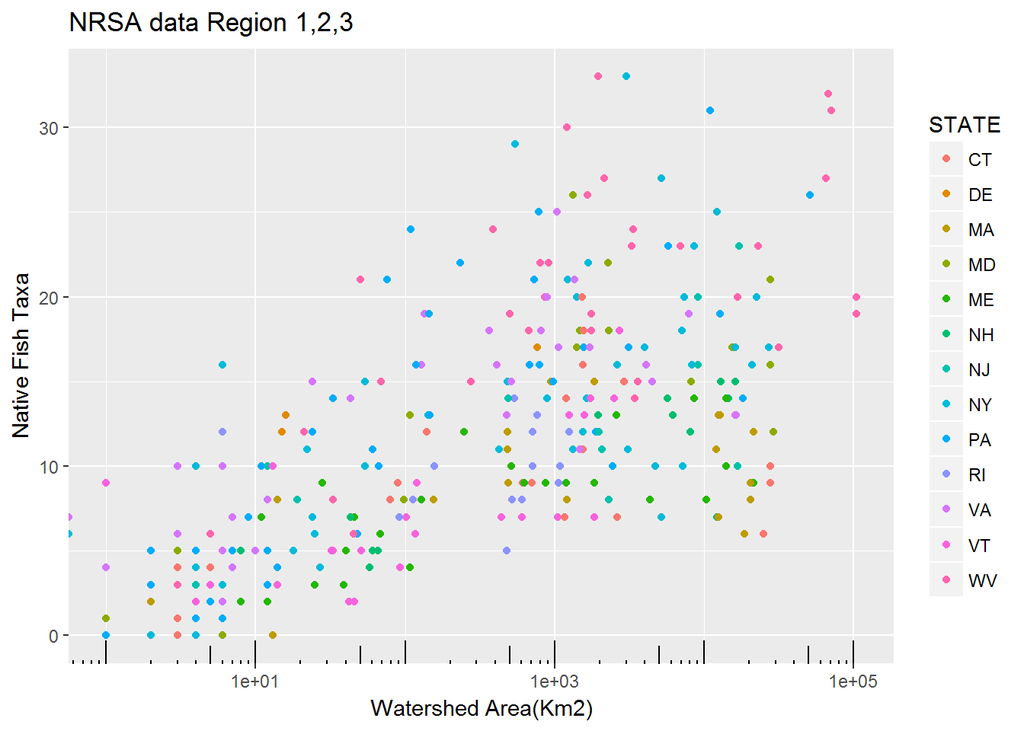

```r
ggplot(nrsa, aes(KM2, NATTAX))+
  geom_point(aes(color=STATE))+
  scale_x_log10()+
labs(title="NRSA data Region 1,2,3", x="Watershed Area(Km2)",y="Native Fish Taxa")+
   annotation_logticks(sides="b", short = unit(.5,"mm"),
  mid = unit(3,"mm"),long = unit(4,"mm"))+
 ggsave("p_sp_area1.jpg")
```

## Some basic data wrangling

It’s helpful to know some basics of data wrangling.  
For example.  
Make that same plot with just sites from Maryland and Pennsylvania.  
Or, instead of using a log scale on the plot, you might want to log transform the values in the dataset as a new variable.

This is not a workshop in data management or wrangling. But it is difficult to separate data visualization from wrangling. One tends to go back and forth quite a bit. I will introduce some basics that might help you get started.

## tidyr, dplyr, and pipes

When data is read into R from a spreadsheet or other source, R creates a dataframe. Certain assumptions are made when doing this, for example, strings (a character variable of one or more characters) are coerced to Factors (which are categorical variables).

More recently, Tibbles have been introduced in dplyr and tibble.  
A tibble (or tbl_df) does not make those assumptions for strings, prints to the screen better, and has some different subset rules.

## dplyr filter() and select() to subset data

Subsets can be used to plot data. There are many was to subset in base R.  
dplyr offers a consistent method.

**filter()** chooses by *row* **select()** chooses by *column*

## mutate new variables

**mutate** creates a new *variable*

dplyr and tidyr are simple and powerful tools to manage data.

https://www.rstudio.com/wp-content/uploads/2015/02/data-wrangling-cheatsheet.pdf

## Filter

The Maryland and Pennsylvania data might be subset from the main NRSA data and then plotted.

#### The %in% operator is how group membership is defined in R

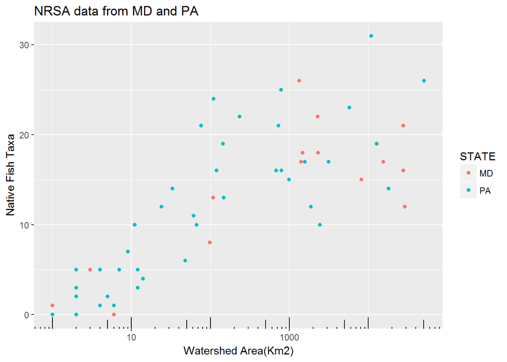

```r
md_pa_nrsa <- filter(nrsa, STATE %in% c("PA", "MD"))

ggplot(md_pa_nrsa, aes(KM2, NATTAX))+
  geom_point(aes(color=STATE))+
  scale_x_log10()+
labs(title="NRSA data from MD and PA", x="Watershed Area(Km2)",y="Native Fish Taxa")+
   annotation_logticks(sides="b", short = unit(.5,"mm"),
  mid = unit(3,"mm"),long = unit(4,"mm"))
```

## Mutate

If we want to add a variable that is the log transformed watershed area, we can use mutate.

There are many other transforms available in R

```r
nrsa <- mutate(nrsa, logwsa=log10(KM2))
```

## Pipes.

Pipe operator. Pipes **%>%** are a way to string code together. You can think of **%>%** as “and then”. It is similar to the + operator in a ggplot.

*CtrlShiftM* is a keyboard shortcut.

The first statement feeds a dataset into the pipe, *and then* it’s filtered, *and then* it’s plotted.

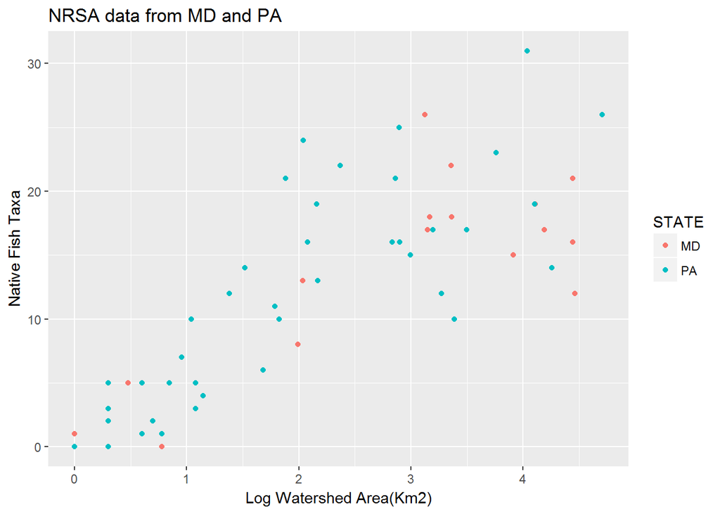

```r
nrsa %>%
  filter(STATE %in% c("PA", "MD")) %>%
ggplot(aes(logwsa, NATTAX))+
  geom_point(aes(color=STATE))+
  labs(title="NRSA data from MD and PA", x="Log Watershed Area(Km2)",y="Native Fish Taxa")
```

## Take some time to make a few more plots

Try some additional labs () arguments like “subtitle=” or “caption=” Break the title into two lines with *

Add more states. Substitute geom_jitter() for geom_point ()

## Order a factor

Changing the order of factor levels may be trivial for a legend key, but this technique is also applicable for changing the order of factors plotted on the x axis. This is not trivial, for example, in a boxplot. If unordered, R will order by alphanumeric.

There are many ways to coerce data from one form to another *as.factor()* *as.character()* etc.

#### Two packages have nice functions for this

read_r and forcats

https://blog.rstudio.com/2016/08/31/forcats-0-1-0/

### This code uses mutate to convert RT_NRSA_CA from a chr to an ordered fct

First, **create a list** of the order of the levels that you want. Then, use **mutate()** to order the factor

*Note: you can also re-order the levels of a factor based on the values of a column of data*

```r
catord <- c("Least Disturbed","Intermediate Disturbance","Most Disturbed")
nrsa<-nrsa %>%
  mutate(RT_NRSA_CA =  factor(RT_NRSA_CA, catord))
```

## Specify colors for a factor

#### If different colors for the factor make sense you need to tell ggplot how you want them using scale_color_manual.

*Note how you “name” the legend*

This shows the previous graph with the levels in a more logical order.

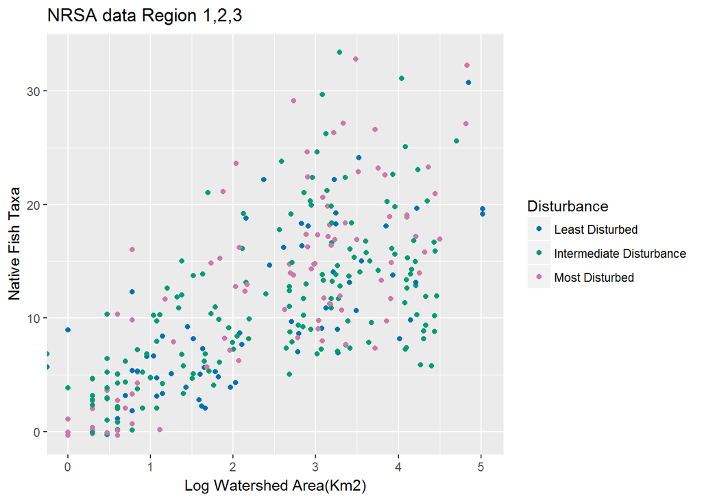

```r
nrsa %>%
   ggplot(aes(logwsa, NATTAX,colour=RT_NRSA_CA))+
  geom_jitter()+
  scale_colour_manual(values=c("Least Disturbed"="#0072B2", "Intermediate Disturbance" = "#009E73", "Most Disturbed" = "#CC79A7"), name= "Disturbance")+
  labs(title="NRSA data Region 1,2,3", x="Log Watershed Area(Km2)",y="Native Fish Taxa")
```

## Superscripts and Subscripts in labels.

*‘expression’*

Add a stat model  
Use geom jitter() to deal with overplotting

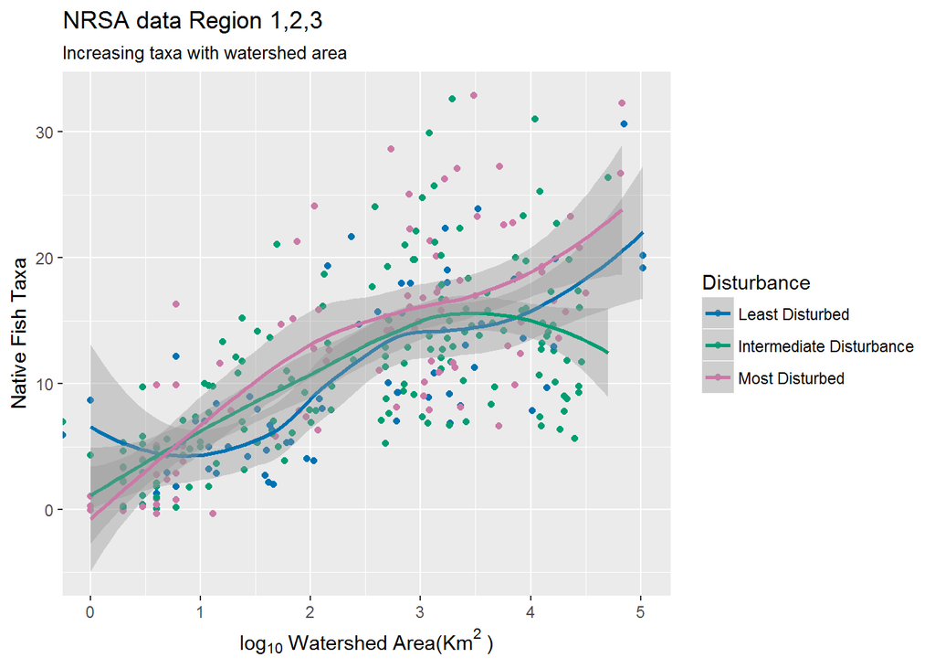

```r
nrsa %>%
   ggplot(aes(logwsa, NATTAX,colour=RT_NRSA_CA))+
  geom_jitter()+
  scale_colour_manual(values=c("Least Disturbed"="#0072B2", "Intermediate Disturbance" = "#009E73", "Most Disturbed" = "#CC79A7"), name= "Disturbance")+
 labs(title="NRSA data Region 1,2,3",subtitle = "Increasing taxa with watershed area",x=expression("log"[10]~"Watershed Area(Km"^2~")"),y="Native Fish Taxa", color="Condition")+ stat_smooth(method="loess")
```

If that is a bit busy, you might prefer facetting the three plots.

## Facet Plots

http://ggplot2.tidyverse.org/reference/facet_grid.html

There are a wide range of facet grids and facet wraps that we can use.

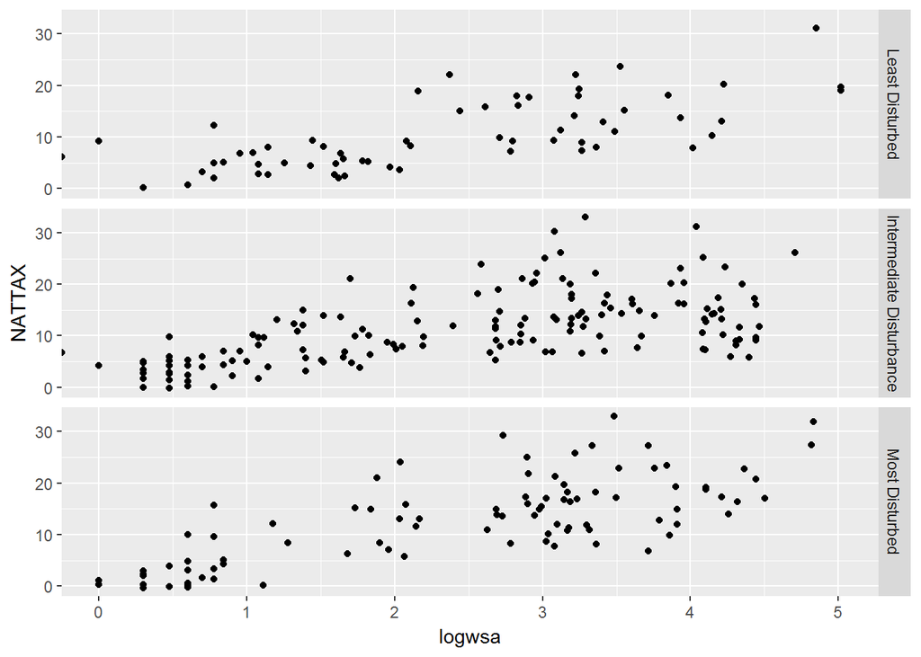

```r
ggplot(nrsa, aes(logwsa, NATTAX))+geom_jitter()+
  facet_grid(RT_NRSA_CA~.)
```

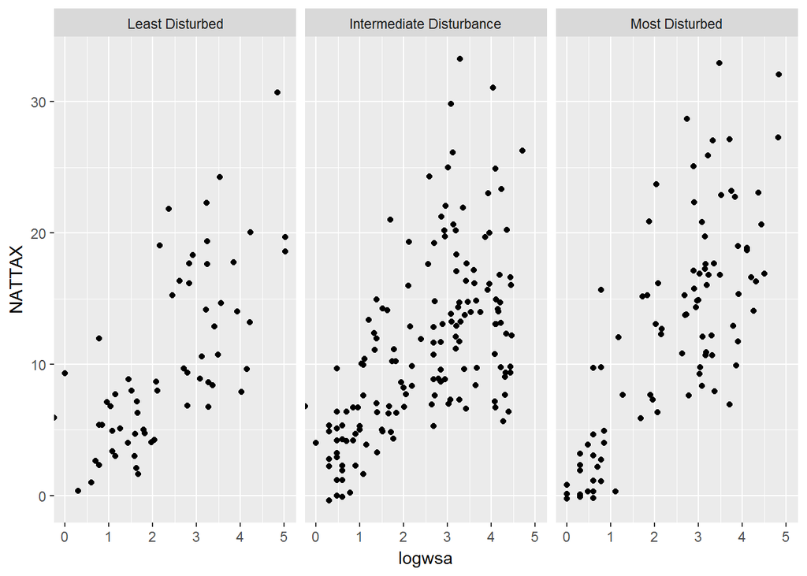

```r
ggplot(nrsa, aes(logwsa, NATTAX))+geom_jitter()+
  facet_grid(.~RT_NRSA_CA)
```

#### Using shorter labels

Use *recode_factor()*  
re-codeing a factor will also allow a change of factor order

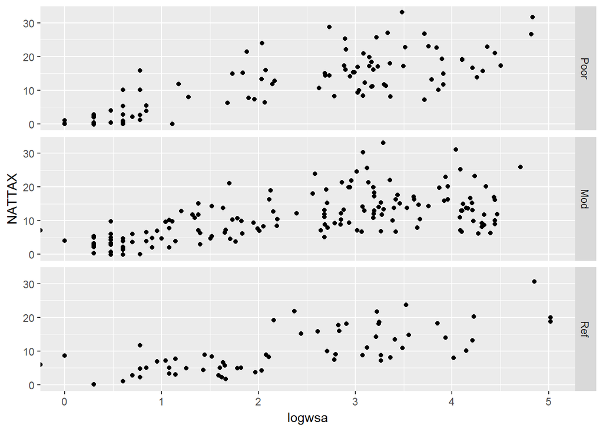

```r
ggplot(nrsa, aes(logwsa, NATTAX))+geom_jitter()+
  facet_grid(.~recode_factor(RT_NRSA_CA,"Most Disturbed" = "Poor","Intermediate Disturbance" = "Mod","Least Disturbed"="Ref")~.)
```

These functions did not reorder or recode the data - just how it appeared in the graph.  
If you wanted to recode and reorder the actual data (as opposed to its appearance on the graphic) then you would have to *mutate* the tibble

```r
nrsa<- nrsa %>%
  mutate(Disturbance = recode_factor(RT_NRSA_CA,"Most Disturbed" = "Poor","Intermediate Disturbance" = "Mod","Least Disturbed"="Ref" ))
```

#### Example of ordering a different factor in a dplyr chain to use in facetting.

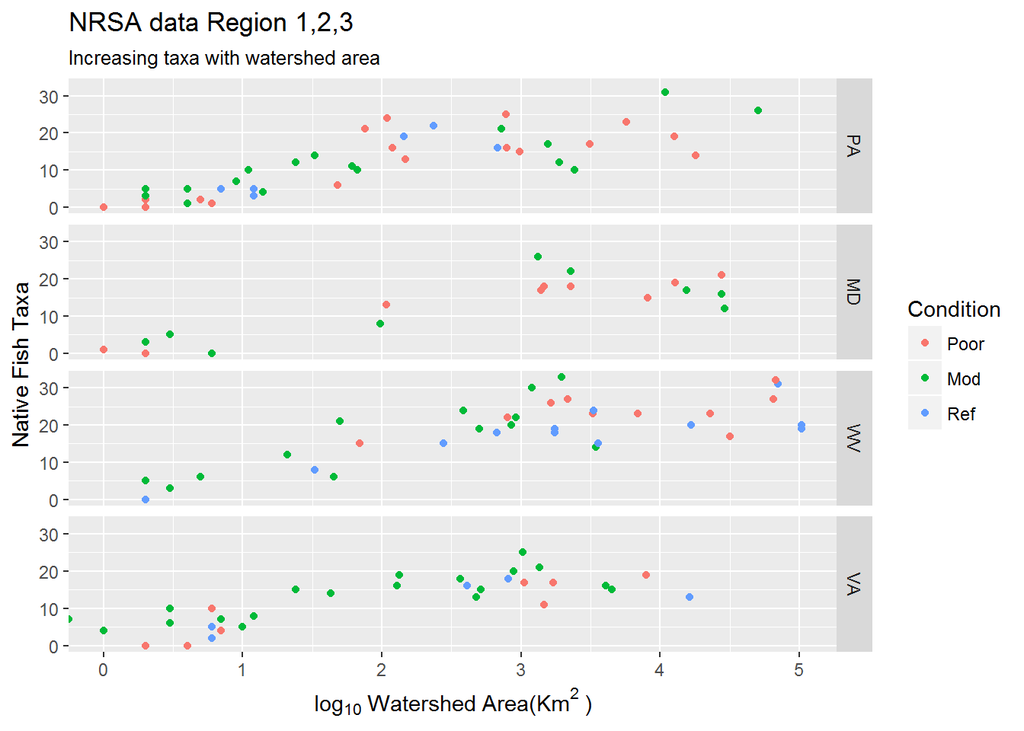

```r
nrsa %>%
  filter(STATE %in% c("PA", "MD","WV","VA")) %>%
  mutate(STATE=factor(STATE, levels=c("PA","MD","WV","VA"))) %>%
  ggplot(aes(logwsa, NATTAX,colour=Disturbance))+
  geom_point()+ facet_grid(STATE ~ .) +
  labs(title="NRSA data Region 1,2,3",subtitle = "Increasing taxa with watershed area",x=expression("log"[10]~"Watershed Area(Km"^2~")"),y="Native Fish Taxa", color="Condition")
```

## Color and color scales

Color can also be used for continuous variables.  
It is good practice to specify a colorblind friendly palette.  
Viridis is one such palette that offers 4 color ramps.  
*viridis color scale also has a discrete option*  
scale_color_viridis(discrete = TRUE)

https://cran.r-project.org/web/packages/viridis/vignettes/intro-to-viridis.html

Specify a different color palette for a continuous variable

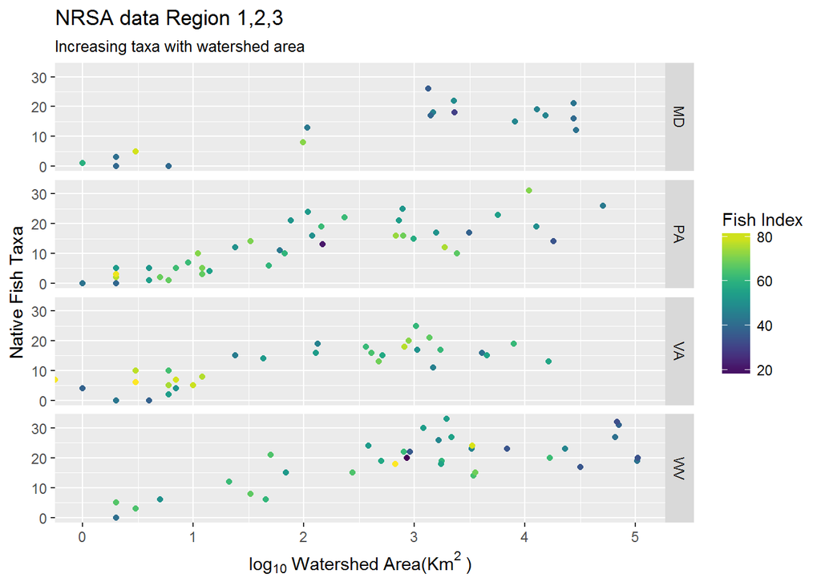

```r
nrsa %>%
  filter(STATE %in% c("PA", "MD","WV","VA")) %>%
   ggplot(aes(logwsa, NATTAX,colour=FISHMMI))+
  geom_point()+ facet_grid(STATE ~ .) +
   scale_color_viridis(option="viridis")+
  labs(title="NRSA data Region 1,2,3",subtitle = "Increasing taxa with watershed area",x=expression("log"[10]~"Watershed Area(Km"^2~")"),y="Native Fish Taxa", color="Fish Index")
```

## Bar Graphs

#### Bar graphs are useful for showing counts and proportions

Make a bar graph using count data  
*Note: use levels() to confirm the ordering or factor levels.*

```r
levels(nrsa$Disturbance)
```

```
## [1] "Poor" "Mod"  "Ref"
```

```r
levels(nrsa$STATE)
```

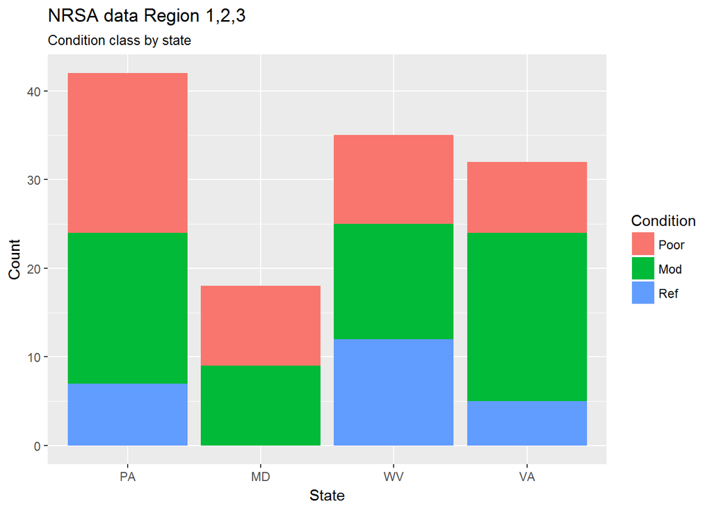

```r
nrsa %>%
  filter(STATE %in% c("PA", "MD","WV","VA")) %>%
  mutate(STATE=factor(STATE, levels=c("PA","MD","WV","VA"))) %>%
  ggplot(aes(STATE))+
  geom_bar(aes(fill=Disturbance))+
  labs(title="NRSA data Region 1,2,3",subtitle = "Condition class by state", x="State",y="Count", fill="Condition")
```

```r
levels(nrsa$STATE)
```

Show as proportion instead of count.  
*Note the **geom_bar()** call*

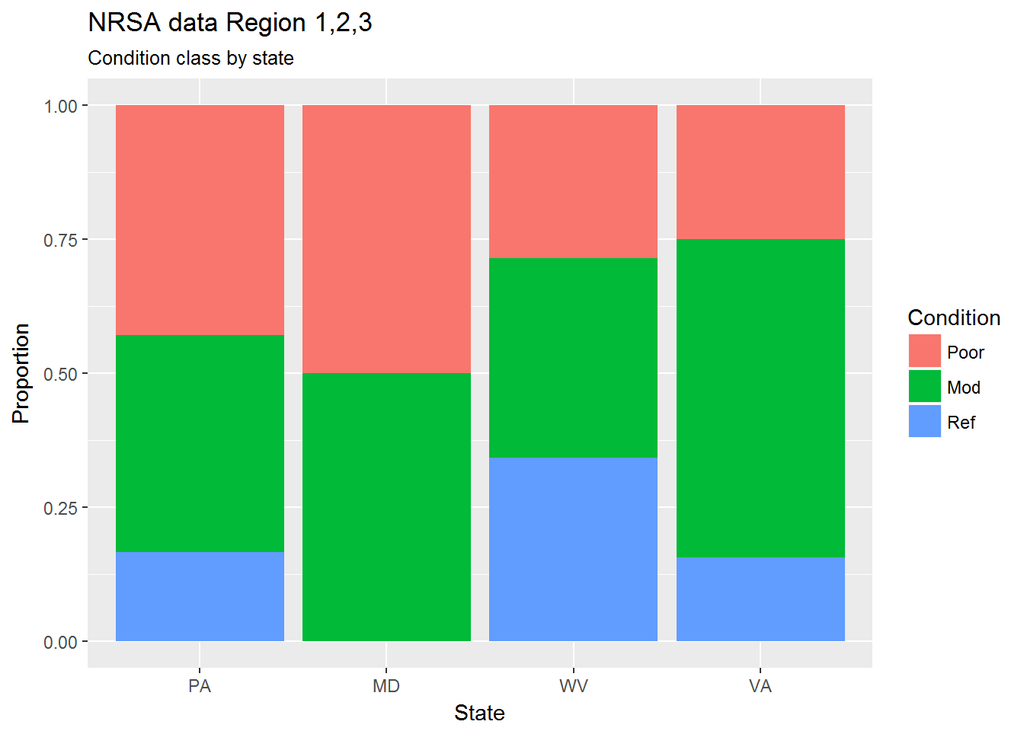

```r
nrsa %>%
  filter(STATE %in% c("PA", "MD","WV","VA")) %>%
  mutate(STATE=factor(STATE,levels=c("PA","MD","WV","VA"))) %>%
  mutate(Disturbance=factor(Disturbance, levels=c("Poor","Mod", "Ref"))) %>%
  ggplot(aes(STATE))+
  scale_colour_manual(values=c("Poor"="#0072B2", "Mod" = "#009E73", "Ref" = "#CC79A7"))+
  geom_bar(aes(fill=Disturbance),position="fill")+
  labs(title="NRSA data Region 1,2,3",subtitle = "Condition class by state", x="State",y="Proportion", fill="Condition")
```

## Plot Identities or Derived Stats ##geom_bar(stat=“identity”…

First some data wrangling to pull out Region 3 states *Note that we will use **names()** to get column positions*  
*bind_rows*  
*filter(!)*

```r
names(fish)
```

```
##  [1] "Type"          "Subpopulation" "Indicator"     "Category"
##  [5] "NResp"         "Estimate.P"    "StdError.P"    "LCB95Pct.P"
##  [9] "UCB95Pct.P"    "Estimate.U"    "StdError.U"    "LCB95Pct.U"
## [13] "UCB95Pct.U"
```

```r
names(bugs)
```

```
##  [1] "Type"          "Subpopulation" "Indicator"     "Category"
##  [5] "NResp"         "Estimate.P"    "StdError.P"    "LCB95Pct.P"
##  [9] "UCB95Pct.P"    "Estimate.U"    "StdError.U"    "LCB95Pct.U"
## [13] "UCB95Pct.U"
```

```r
head(bugs, 10)
```

```
## # A tibble: 10 x 13
##               Type Subpopulation       Indicator     Category NResp
##              <chr>         <chr>           <chr>        <chr> <dbl>
##  1        National      National MacroInvert_MMI         Good   574
##  2        National      National MacroInvert_MMI         Fair   431
##  3        National      National MacroInvert_MMI         Poor   878
##  4        National      National MacroInvert_MMI Not Assessed    41
##  5        National      National MacroInvert_MMI        Total  1924
##  6 WSA3_Ecoregions         EHIGH MacroInvert_MMI         Good   136
##  7 WSA3_Ecoregions         EHIGH MacroInvert_MMI         Fair   111
##  8 WSA3_Ecoregions         EHIGH MacroInvert_MMI         Poor   256
##  9 WSA3_Ecoregions         EHIGH MacroInvert_MMI Not Assessed    17
## 10 WSA3_Ecoregions         EHIGH MacroInvert_MMI        Total   520
## # ... with 8 more variables: Estimate.P <dbl>, StdError.P <dbl>,
## #   LCB95Pct.P <dbl>, UCB95Pct.P <dbl>, Estimate.U <dbl>,
## #   StdError.U <dbl>, LCB95Pct.U <dbl>, UCB95Pct.U <dbl>
```

```r
fishR3 <- fish %>%
  filter(Subpopulation==3)
bugsR3 <- bugs %>%
  filter(Subpopulation==3)

fb3 <- bind_rows(fishR3, bugsR3)
names(fb3)
```

```
##  [1] "Type"          "Subpopulation" "Indicator"     "Category"
##  [5] "NResp"         "Estimate.P"    "StdError.P"    "LCB95Pct.P"
##  [9] "UCB95Pct.P"    "Estimate.U"    "StdError.U"    "LCB95Pct.U"
## [13] "UCB95Pct.U"
```

```r
fb <- fb3 %>%
  select(2:4,6,7,8,9) %>%
  filter(!Category=="Total")
```

*Note - reverse of the order of the legend and compare plots*

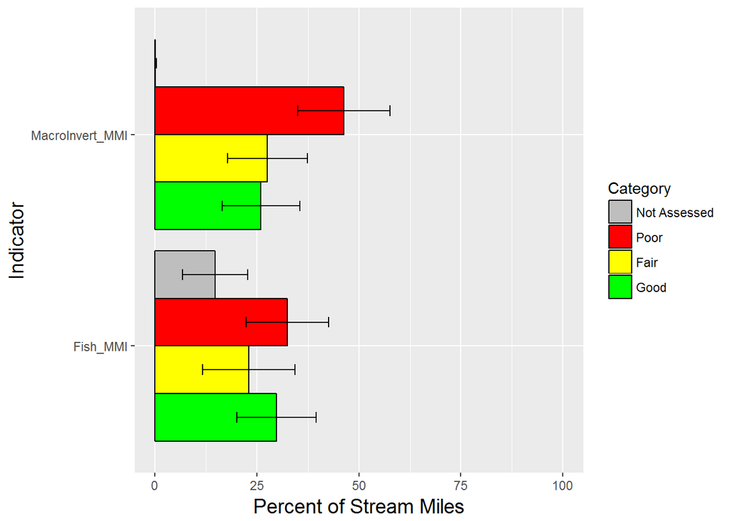

```r
fb$Category=factor(fb$Category, levels=c("Good", "Fair", "Poor", "Not Assessed"))

fb %>%
  mutate(cb=UCB95Pct.P-Estimate.P) %>%
  ggplot(aes(Indicator,Estimate.P, fill=Category))+
  geom_bar(stat="identity", position="dodge", colour="black")+
  geom_errorbar(stat="identity",aes(ymin=Estimate.P+cb, ymax=Estimate.P-cb),
                position=position_dodge(0.9), width=.2)+
  scale_fill_manual(values=c("Good" ="green", "Fair"="yellow", "Poor"="red", "Not Assessed"="grey" ,name="Category"))+
  ylab("Percent of Stream Miles")+theme(axis.title.y=element_text(size=14))+
  theme(axis.title.x=element_text(size=14))+
  scale_y_continuous(limits=c(0,100))+
  guides(fill=guide_legend(reverse=TRUE))+
  coord_flip()
```

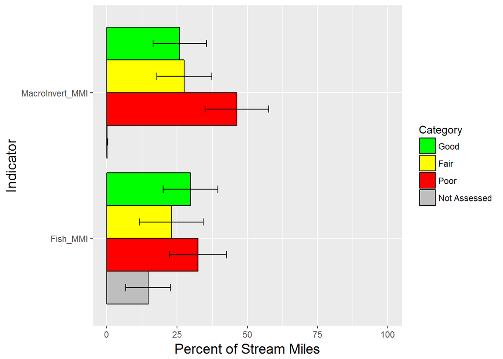

```r
#Reorder the levels of this factor
fb$Category=factor(fb$Category, levels=c("Not Assessed","Poor","Fair","Good"))

fb %>%
  mutate(cb=UCB95Pct.P-Estimate.P) %>%
  ggplot(aes(Indicator,Estimate.P, fill=Category))+
  geom_bar(stat="identity", position="dodge", colour="black")+
  geom_errorbar(stat="identity",aes(ymin=Estimate.P+cb, ymax=Estimate.P-cb),
                position=position_dodge(0.9), width=.2)+
  scale_fill_manual(values=c("Good" ="green", "Fair"="yellow", "Poor"="red", "Not Assessed"="grey" ,name="Category"))+
  guides(fill=guide_legend(reverse=TRUE))+
  ylab("Percent of Stream Miles")+theme(axis.title.y=element_text(size=14))+
  theme(axis.title.x=element_text(size=14))+
  scale_y_continuous(limits=c(0,100))+
  coord_flip()
```

http://ggplot2.tidyverse.org/reference/geom_boxplot.html

#### Boxplots show the median, (50% quantile) the 25% and 75% quantiles, whiskers (1.5*IQR past upper and lower hinge), and outlying points past the whiskers

#### Basic Boxplot

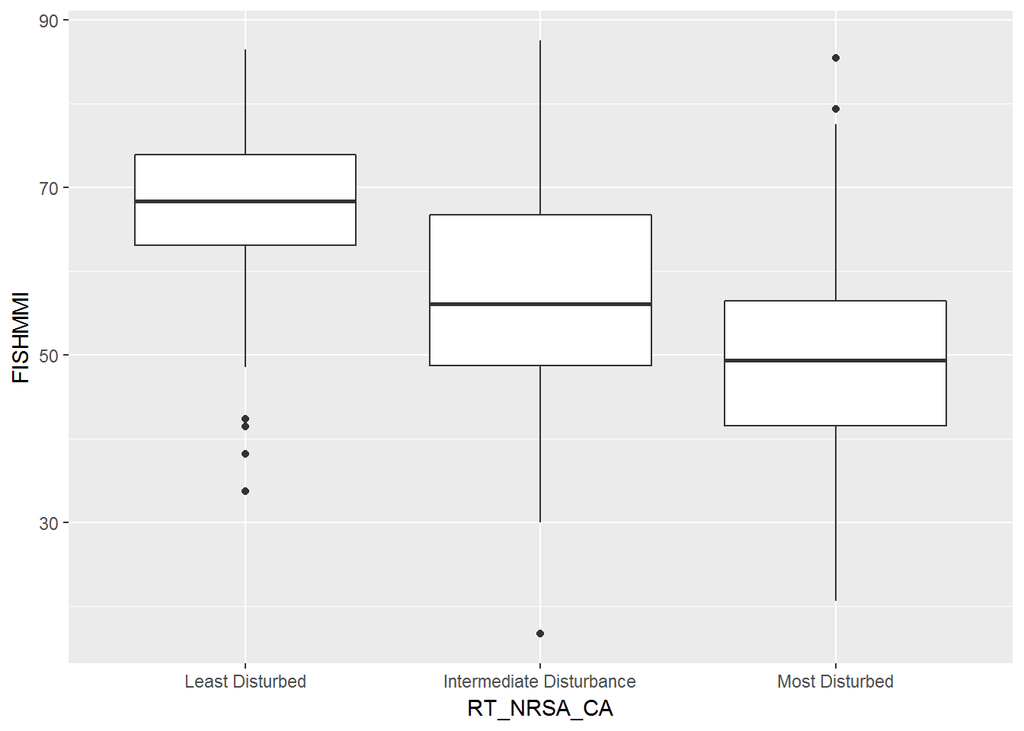

```r
ggplot(nrsa, aes(RT_NRSA_CA, FISHMMI))+geom_boxplot()
```

## Themes

theme() is used within an element call to adjust specs  
theme_ is used to control the theme of the entire plot

Add titles and new axis labels. Compare the looks of these two plots

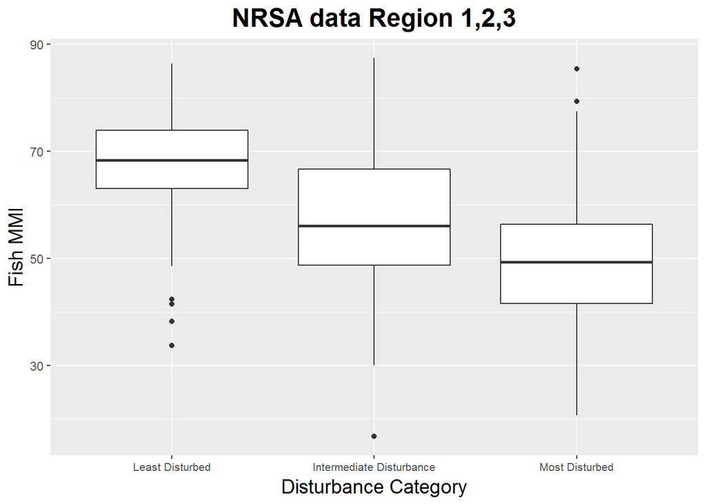

```r
ggplot(nrsa, aes(RT_NRSA_CA, FISHMMI))+geom_boxplot()+
  ggtitle("NRSA data Region 1,2,3")+theme(plot.title = element_text(size = 18,face="bold",hjust=0.5))+
  ylab("Fish MMI")+theme(axis.title.y=element_text(size=14))+
  xlab("Disturbance Category")+theme(axis.title.x=element_text(size=14))+
  theme(axis.text.x = element_text(size=8,angle=0))
```

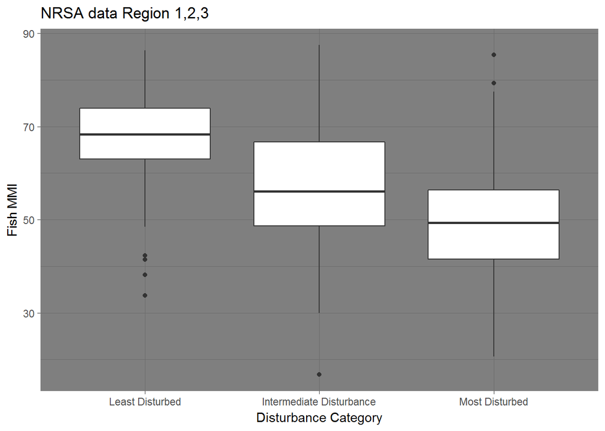

```r
ggplot(nrsa, aes(RT_NRSA_CA, FISHMMI))+geom_boxplot()+
  ggtitle("NRSA data Region 1,2,3")+theme(plot.title = element_text(size = 18,face="bold",hjust=0.5))+
  ylab("Fish MMI")+theme(axis.title.y=element_text(size=14))+
  xlab("Disturbance Category")+theme(axis.title.x=element_text(size=14))+
  theme(axis.text.x = element_text(size=8,angle=0))+
  theme_dark()
```

## Jittered boxplots and violin plots

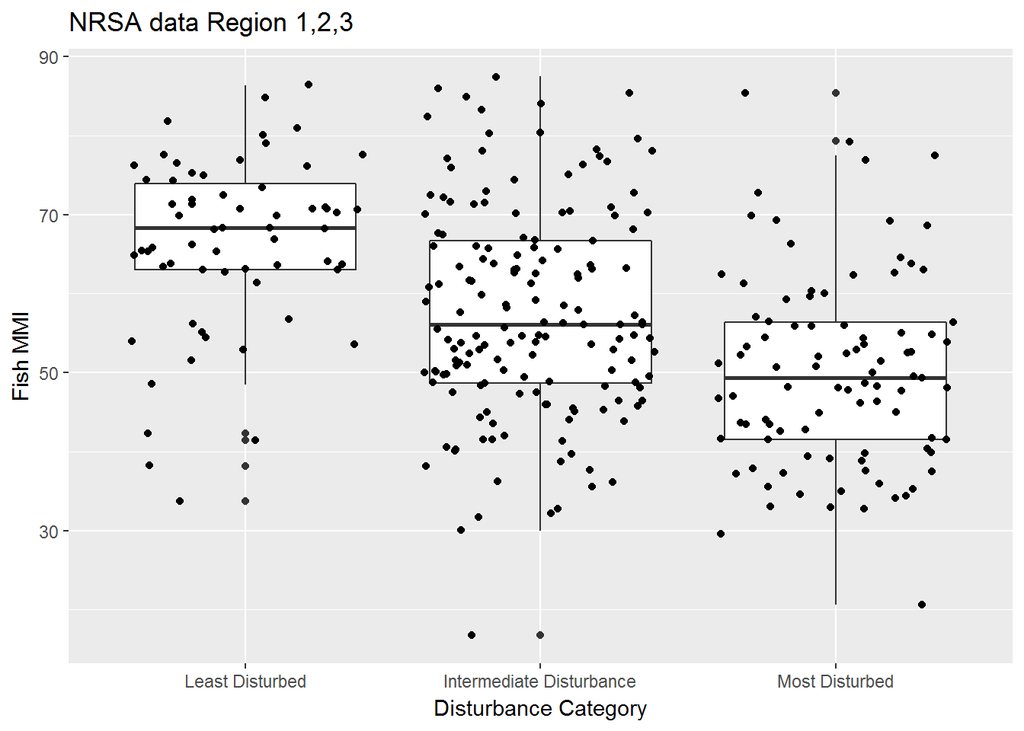

```r
ggplot(nrsa, aes(RT_NRSA_CA, FISHMMI))+
  geom_boxplot(outier.shape=NA)+
  geom_jitter()+
  labs(title="NRSA data Region 1,2,3",y="Fish MMI", x="Disturbance Category")
```

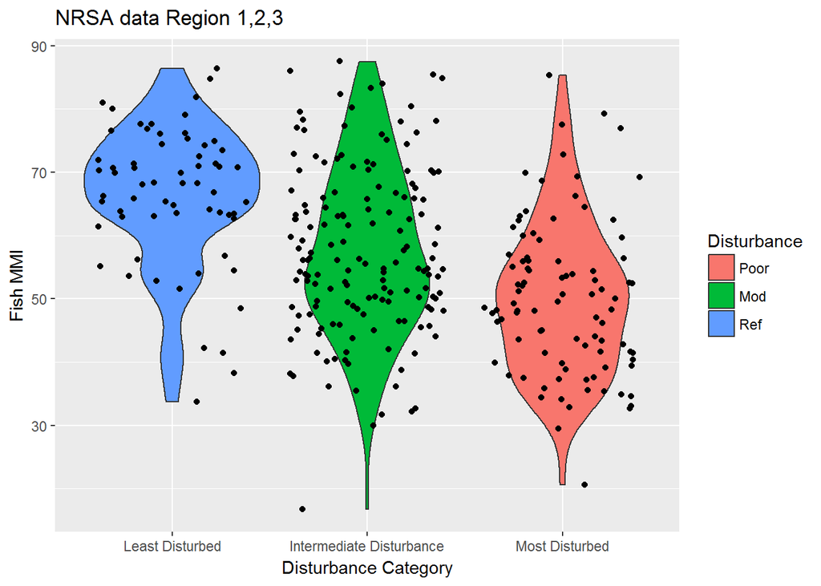

```r
ggplot(nrsa, aes(RT_NRSA_CA, FISHMMI))+
  geom_violin(aes(fill=Disturbance))+
  geom_jitter()+
  labs(title="NRSA data Region 1,2,3",y="Fish MMI", x="Disturbance Category")
```

#### Now lets add some covariates to this graph.

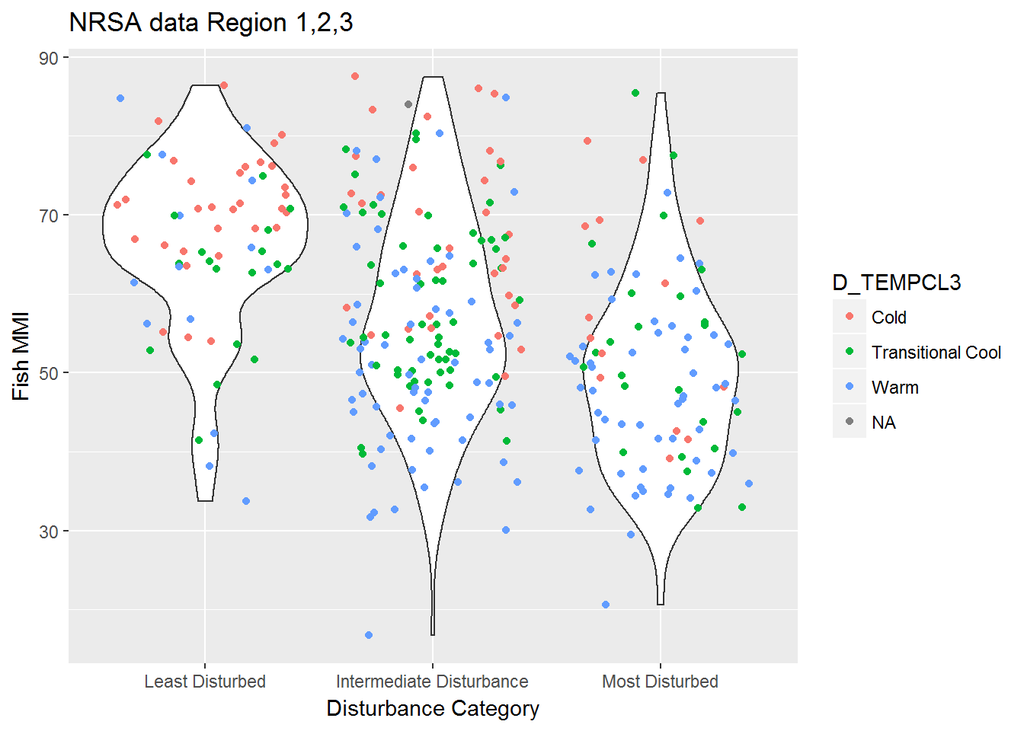

```r
ggplot(nrsa, aes(RT_NRSA_CA, FISHMMI))+
  geom_violin()+
  geom_jitter(aes(color=D_TEMPCL3))+
  labs(title="NRSA data Region 1,2,3",y="Fish MMI", x="Disturbance Category")
```

### More ordered factors

Because we are trying to convey information - and most folks associate red with warm, we would want to fix this

#### A note on NA

Generally, when exploring data, it is a good idea to visualize NAs so that you can see if there is any pattern in NA. Once you are comfortable that is is just a few random points, you can filter them.

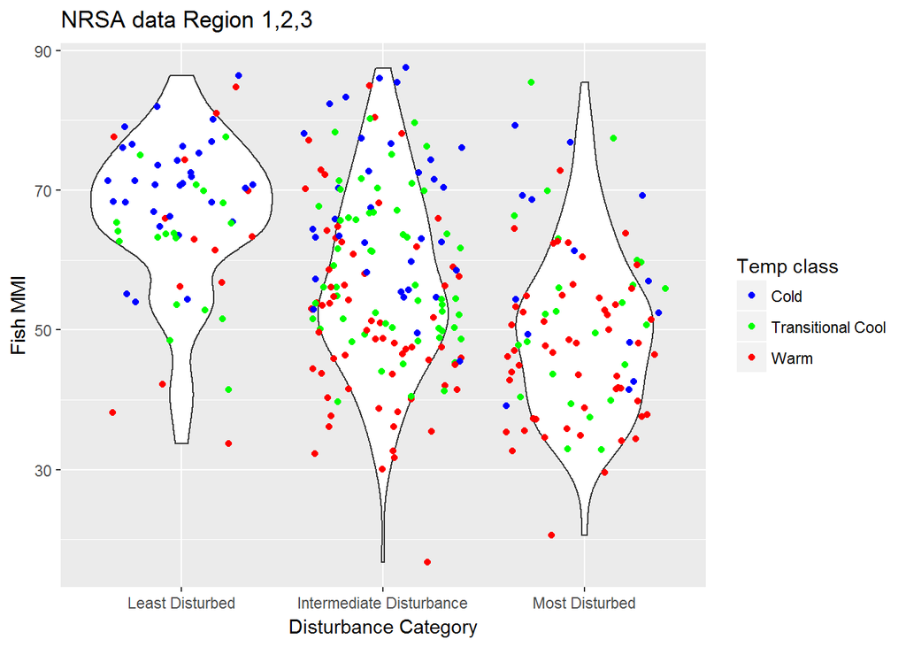

```r
nrsa %>%
  filter(!D_TEMPCL3=="NA") %>%
ggplot(aes(RT_NRSA_CA, FISHMMI))+
  geom_violin()+
  geom_jitter(aes(color=D_TEMPCL3))+
  labs(title="NRSA data Region 1,2,3",y="Fish MMI", x="Disturbance Category")+
   scale_colour_manual(values=c("Cold" ="blue", "Transitional Cool"="green", "Warm"="red"),name="Temp class")
```

## Map more than one factor

#### Avoid combining shapes with sizes of points

*Note added a command **alpha=**to adjust the transparency of the points to help with overplotting*

```r
sum(is.na(nrsa$D_TEMPCL3))
```

```
## [1] 1
```

```r
sum(is.na(nrsa$logwsa))
```

```
## [1] 0
```

```r
sum(is.na(nrsa$ELECTROFISH))
```

```
## [1] 0
```

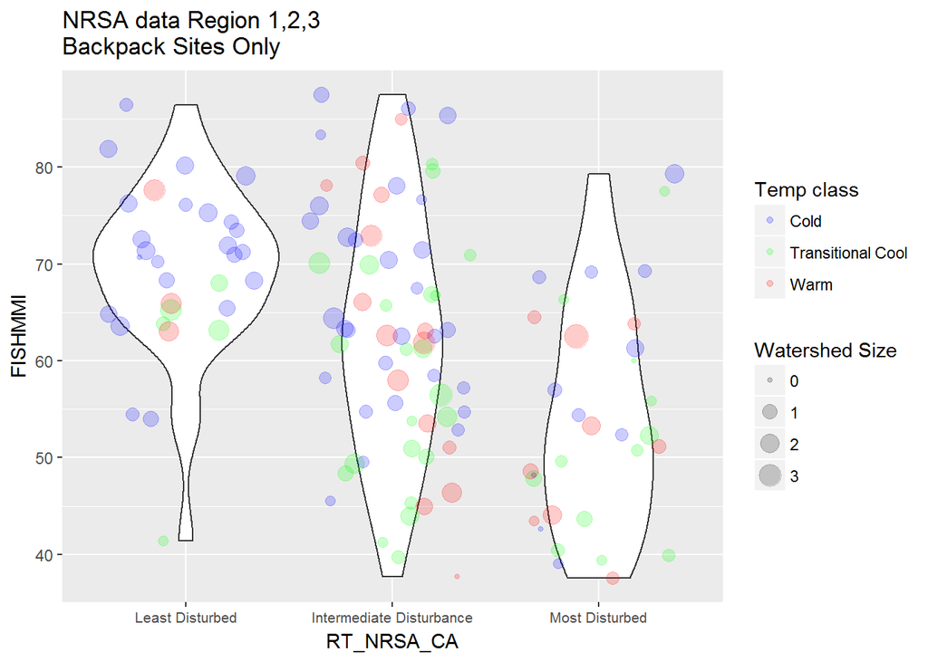

```r
nrsa %>%
  filter(ELECTROFISH=="BP") %>%
  filter(!is.na(D_TEMPCL3)) %>%
ggplot(aes(RT_NRSA_CA,FISHMMI))+
  geom_violin()+
    labs(title = "NRSA data Region 1,2,3\nBackpack Sites Only",
  ylab="Fish MMI",xlab="Disturbance Category")+
  theme(axis.text.x = element_text(size=8,angle=0))+
  geom_jitter(aes(color=D_TEMPCL3, size=logwsa), alpha=0.2)+
  scale_colour_manual(values=c("Cold" ="blue", "Transitional Cool"="green", "Warm"="red" ),name="Temp class")+
  scale_size_continuous(name="Watershed Size")
```

## Further

If we got to this point, and there is still time and we want to, we will cover the following.

## broom()

Read in data to explore wrangling models

```r
rawmets = read_excel("VisData.xlsx","rawmets")
```

## Using ggplot with linear models

When a linear model is run is R, results are put into a list. summary statistics must be extracted from this list. For example

```r
rich_mod <- lm(rawmets$R_FISH~rawmets$CUMU_DA_KM2)
rich_mod
```

```
##
## Call:
## lm(formula = rawmets$R_FISH ~ rawmets$CUMU_DA_KM2)
##
## Coefficients:
##         (Intercept)  rawmets$CUMU_DA_KM2
##            10.31234              0.04536
```

```r
summary(rich_mod)
```

```
##
## Call:
## lm(formula = rawmets$R_FISH ~ rawmets$CUMU_DA_KM2)
##
## Residuals:
##      Min       1Q   Median       3Q      Max
## -19.9560  -5.2310  -0.6294   4.4691  19.6474
##
## Coefficients:
##                      Estimate Std. Error t value Pr(>|t|)
## (Intercept)         10.312338   0.293343   35.15   <2e-16 ***
## rawmets$CUMU_DA_KM2  0.045364   0.002631   17.24   <2e-16 ***
## ---
## Signif. codes:  0 '***' 0.001 '**' 0.01 '*' 0.05 '.' 0.1 ' ' 1
##
## Residual standard error: 6.707 on 945 degrees of freedom
## Multiple R-squared:  0.2393, Adjusted R-squared:  0.2384
## F-statistic: 297.2 on 1 and 945 DF,  p-value: < 2.2e-16
```

If all you have is one model that you are interested in, base R with *summary()* is adequate.

But if you are going to look at a few models…

## broom()

wrangle the results of models (and many other outputs)

https://cran.r-project.org/web/packages/broom/vignettes/broom.html

Firstly, and usually, we need to wrangle data.

## gather() and spread() from *tidyr*

Dataframes come in two forms - **long and wide**

All of the dataframes currently in our R environment are in wide format.

*gather() gathers columns together into fewer columns.*  
*spread() spreads columns out across more columns.*

```r
out_long <- rawmets %>%
  mutate(logWSA=log10(CUMU_DA_KM2)) %>%
  select(-CUMU_DA_KM2,-FinalIBIRegion) %>%
  gather('METRIC', 'METVAL', -c(EventID, logWSA, REF_CLASS))
```

Filter reference sites only

```r
  out_long2 <- out_long %>%
  filter(REF_CLASS<2) %>%
  select (-REF_CLASS)

#make sure there are no missing logWSA)
sum(is.na(out_long2))
```

```
## [1] 0
```

## Regression model statistics

## glance() and do() from the broom package

*Note **group_by()** call*

```r
library(broom)

reg_stats <- out_long2 %>%
  group_by(METRIC) %>%
  do(glance(lm(METVAL~logWSA,.)))

head(reg_stats)
```

```
## # A tibble: 6 x 12
## # Groups:   METRIC [6]
##           METRIC  r.squared adj.r.squared       sigma statistic
##            <chr>      <dbl>         <dbl>       <dbl>     <dbl>
## 1         I_FISH 0.16851388   0.160199014 606.3663692 20.266589
## 2      P_Benthic 0.13945274   0.130847264   0.2198722 16.205122
## 3 P_Benthic_CACO 0.13298983   0.124319728   0.2197669 15.338901
## 4     P_Benthic2 0.01348071   0.003615512   0.2286139  1.366492
## 5     P_BENTHIC2 0.08654034   0.077405739   0.2494981  9.473909
## 6 P_Benthic2.DEP 0.01845660   0.008641164   0.1956754  1.880365
## # ... with 7 more variables: p.value <dbl>, df <int>, logLik <dbl>,
## #   AIC <dbl>, BIC <dbl>, deviance <dbl>, df.residual <int>
```

reg_stats is a tibble. As such, it can be wrangled. *Subset the significant models*

```r
reg_sig <- reg_stats %>%
  filter(p.value<=.05) %>%
  filter(!p.value=="NaN")
```

## Save residuals and other output by obs:

## augment()

```r
reg_vals <- out_long2 %>%
  group_by(METRIC) %>%
  do(augment(lm(METVAL~logWSA,.)))
head(reg_vals)
```

```
## # A tibble: 6 x 10
## # Groups:   METRIC [1]
##   METRIC METVAL   logWSA   .fitted  .se.fit     .resid       .hat   .sigma
##    <chr>  <dbl>    <dbl>     <dbl>    <dbl>      <dbl>      <dbl>    <dbl>
## 1 I_FISH     67 1.329093  607.3613 70.45399 -540.36130 0.01350023 606.9632
## 2 I_FISH    153 2.081239 1080.7274 90.92532 -927.72743 0.02248534 602.0801
## 3 I_FISH    309 1.978970 1016.3638 80.74210 -707.36381 0.01773086 605.1849
## 4 I_FISH    808 1.699491  840.4727 61.86431  -32.47272 0.01040903 609.4123
## 5 I_FISH    311 2.138325 1116.6544 97.06176 -805.65442 0.02562277 603.8753
## 6 I_FISH   1122 1.907153  971.1658 74.40459  150.83419 0.01505668 609.2297
## # ... with 2 more variables: .cooksd <dbl>, .std.resid <dbl>
```

## Save Regression model coefficients:

## tidy()

*The following will save the slopes and intercepts into two separate tables* *Note the renaming of the variables to slope_est and intcpt_est within the select call*

```r
reg_out <- out_long2 %>%
  group_by(METRIC) %>%
  do(tidy(lm(METVAL~logWSA,.)))
head(reg_out)
```

```
## # A tibble: 6 x 6
## # Groups:   METRIC [3]
##           METRIC        term     estimate    std.error  statistic
##            <chr>       <chr>        <dbl>        <dbl>      <dbl>
## 1         I_FISH (Intercept) -229.1078433 230.62357356 -0.9934277
## 2         I_FISH      logWSA  629.3535287 139.79908909  4.5018428
## 3      P_Benthic (Intercept)    0.9319229   0.08362554 11.1439981
## 4      P_Benthic      logWSA   -0.2040637   0.05069202 -4.0255586
## 5 P_Benthic_CACO (Intercept)    0.9102318   0.08358550 10.8898291
## 6 P_Benthic_CACO      logWSA   -0.1984398   0.05066774 -3.9164909
## # ... with 1 more variables: p.value <dbl>
```

```r
glimpse(reg_out)
```

```
## Observations: 454
## Variables: 6
## $ METRIC    <chr> "I_FISH", "I_FISH", "P_Benthic", "P_Benthic", "P_Ben...
## $ term      <chr> "(Intercept)", "logWSA", "(Intercept)", "logWSA", "(...
## $ estimate  <dbl> -2.291078e+02, 6.293535e+02, 9.319229e-01, -2.040637...
## $ std.error <dbl> 2.306236e+02, 1.397991e+02, 8.362554e-02, 5.069202e-...
## $ statistic <dbl> -0.9934277, 4.5018428, 11.1439981, -4.0255586, 10.88...
## $ p.value   <dbl> 3.228993e-01, 1.825262e-05, 3.126583e-19, 1.107081e-...
```

```r
#Grab just the slope estimates into a dataframe
reg_sl <- reg_out %>%
  filter(term =='logWSA') %>%
  select(METRIC, slope_est=estimate)

#Grab just the intercept estimates into a dataframe
reg_int <- reg_out %>%
  filter(term =='(Intercept)') %>%
  select(METRIC, intcpt_est=estimate)
```

## Joins

R can perform database joins. We will use dplyr for this function.

Make a tibble of regression coeeficients for the significant models

```r
regcorr <- left_join(reg_sig, reg_sl, by="METRIC")
regcorr2 <- left_join(regcorr, reg_int, by="METRIC")
names(regcorr2)
```

```
##  [1] "METRIC"        "r.squared"     "adj.r.squared" "sigma"
##  [5] "statistic"     "p.value"       "df"            "logLik"
##  [9] "AIC"           "BIC"           "deviance"      "df.residual"
## [13] "slope_est"     "intcpt_est"
```

```r
regcorr3 <- regcorr2 %>%
  select(METRIC, slope_est, intcpt_est)

#Join the regression coefficients to all the sites
#It really does matter which file you list first in a left_join!!!

reg_correct <- left_join(out_long, regcorr3,by="METRIC")
#Create the Adjusted Scores
reg_correct <- reg_correct %>%
  mutate(Exp = logWSA*slope_est+intcpt_est,
         METVAL_2=METVAL/Exp)

sig_models <- left_join(regcorr3,out_long, by="METRIC")
```